# *Kaggle Cars Dataset Exploration*

## *Preliminary Wrangling*

*This document explores a dataset containing car brands and their engineering attributes for approximately **261** models.*

*No missing values are present in the data.*

*All entries are unique, there are no duplicated rows.*

## *Cleaning Steps:*

- *Remove whitespaces in column names.*
- *Convert **cubicinches** & **weightlbs** into integer type.*

## *The structure of the dataset:*

*There are **261** car models in the dataset with **8** features: `mpg`, `cylinders`, `cubicinches`, `hp`, `weightlbs`, `time-to-60`, `year` and `brand`. Most variables are numeric in nature, except for the variable **brand**, which is a categorical variable and the **year** variable, which is a period.*

## *The main features of interest in the dataset:*

*I'm interested in figuring out how **mpg**, **cylinders**, **cubicinches**, **hp**, **weightlbs**, **time-to-60**, **year**, and **brand** are related to one another in the dataset, specifically, how these variables change overtime.*

## *The features in the dataset that I think will help support the investigation into the features of interest:*

*All previously mentioned features will provide great insights into how models' size, speed, force, weight, and fuel consumption have changed across time and place.*

## *Univariate Exploration*

*In this section, we'll investigate distributions of individual variables.*

## *1. Distribution of Miles Per Gallon*

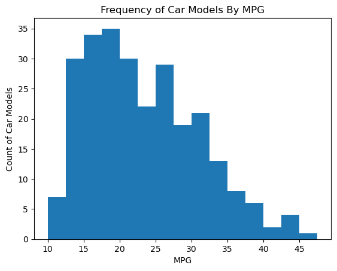

*The **mpg** histogram is skewed to the right. Car models with higher miles per gallon are lower in frequency. The number of car models increases, as the miles per gallon variable decreases, meaning that fewer car models achieve the highest efficiency regarding fuel consumption.*

## *2. Distribution of Number of Cylinders*

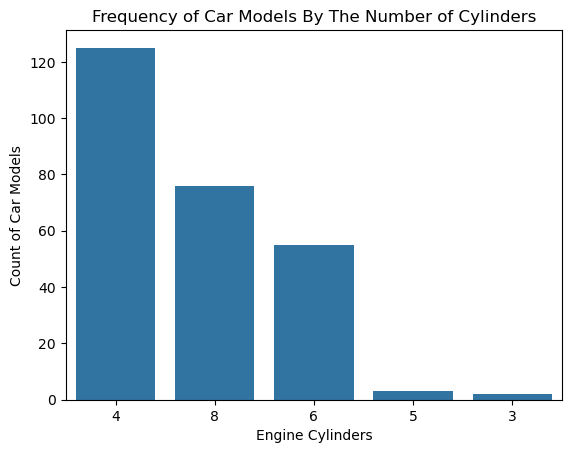

*The **cylinders** Pareto chart shows that cars with engines of **4** cylinders are the most frequent then cars with **8** cylinders, **6** cylinders, **5**, and lastly **3** cylinders.*

## *3. Distribution of Horsepower*

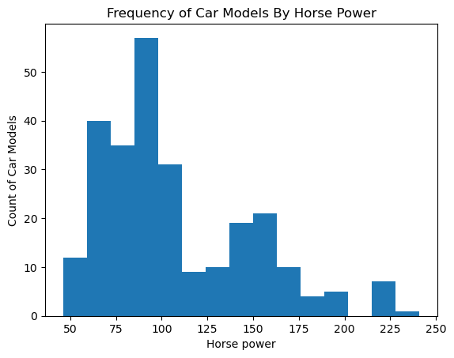

*The **hp** histogram is skewed to the right. As horsepower increases, the frequency decreases. Most cars are ranged between **50** and **150** for horse power.*

## *4. Distribution of Time-To-60*

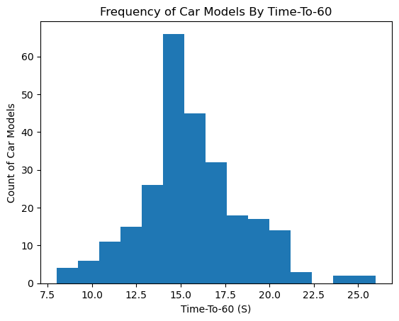

*The **time-to-60** histogram is unimodal. As for time-to-60 variable, most cars in the dataset take about **10-20** seconds to reach 60 miles per hour.*

## *5. Distribution of Brand*

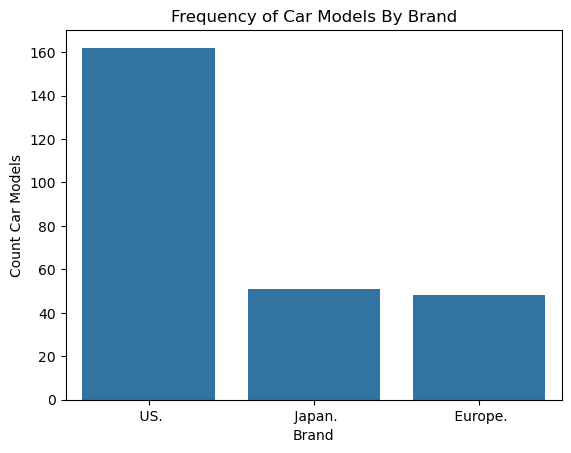

*The **brand** bar chart shows that most cars in our dataset are US brands then Japanese and lastly European.*

## *6. Distribution of Year*

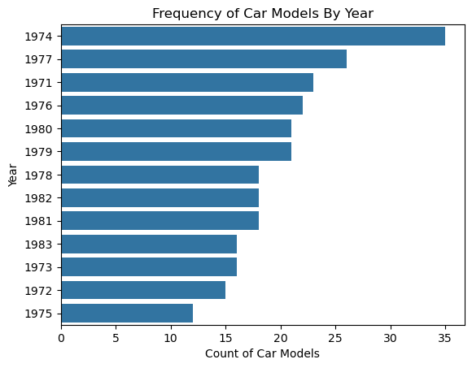

*From the **year** Pareto chart all the car models in the dataset were designed in the seventies and the eighties. The top five years regarding the number of models are **1974**, **1977**, **1971**, **1976**, and **1980** or **1979** given that these two years have the same count of car models.*

## *7. Distribution of Cubicinches*

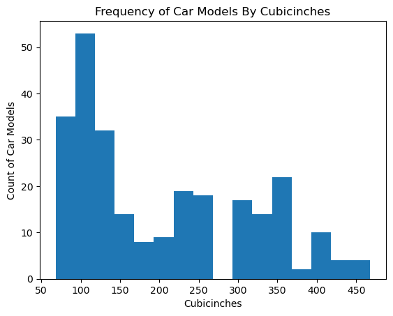

*The **cubicinches** histogram is skewed to the right. The higher this feature, the lower the frequency in the data. Most cars range between **100** and **350**.*

## *8. Distribution of Weights*

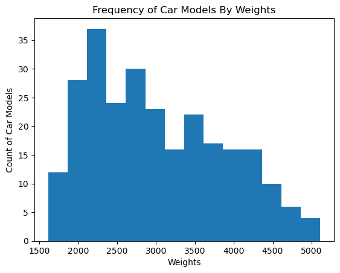

*The **weightlbs** histogram is skewed to the right. As cars weight increases, the frequency of such models decreases in the data.*

### *Conclusion of The Univariate Exploration:*

*Visualizing **mpg** via histogram showed fewer models have higher mpg. Building a Pareto chart for the **cylinders** feature revealed that most models have **4**-cylinder engines. The **hp** histogram is skewed to the right. As horsepower increases, the frequency decreases. As with horsepower, most models range between **50** and **150**. Regarding **time-to-60**, most models take about **15** seconds to reach 60 miles per hour. Most cars in the data are US models according to the **brand** Pareto chart. These models were designed in the seventies and the eighties, as the **year** Pareto chart shows. The top five years about the number of brands are **1974**, **1977**, **1971**, **1976**, and **1980** or **1979**. The **cubicinches** histogram is skewed to the right. Higher cubicinches involve lower frequency. The **cubicinches** feature mostly ranges between **100** and **350**. The **weightlbs** histogram is skewed to the right. When the car's weight increases, the frequency decreases. Most models weigh about **1500** and **4500** pounds.*

## *Bivariate Exploration*

*In this section, we'll investigate relationships between pairs of variables in our data.*

## *1. Cubicinches Vs. Weights*

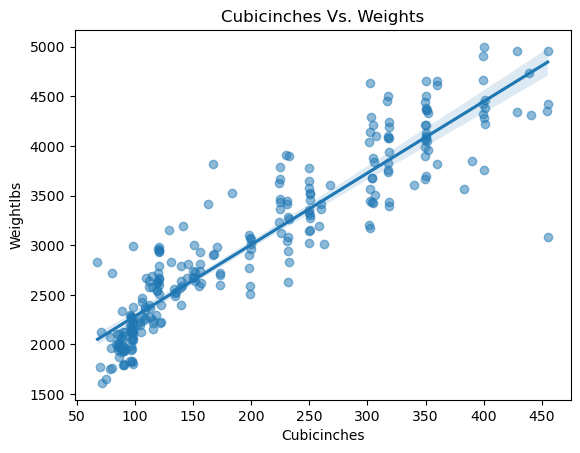

*The scatterplot shows the positive correlation between **cubicinches** and **weightlbs**. Very intuitive and clear. Both the size of the car and its weight are positively correlated. The larger the car model, the heavier it gets.*

## *2. Weights Vs. Miles Per Gallon*

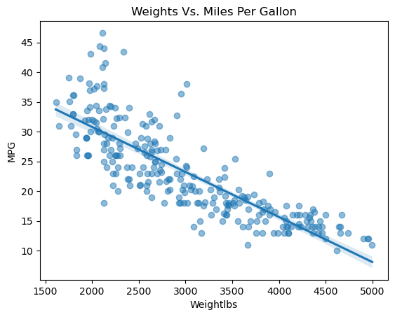

*The scatterplot shows the negative correlation between **weightlbs** and **mpg**. As we can see from this scatterplot, the heavier the car model, the fewer miles it travels per gallon, meaning it consumes much more fuel, which makes sense, right?! Logically, the same applies to the size of the car, given that the weight and the size of the car are positively correlated.*

## *3. Horsepower Vs. Time-To-60*

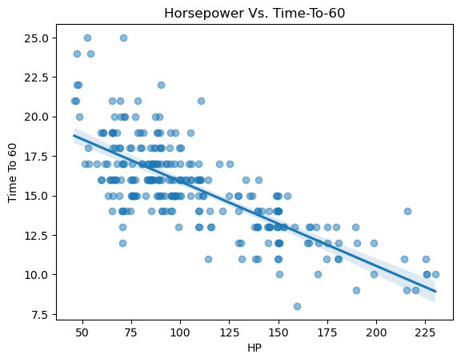

*The scatterplot shows the negative correlation between **hp** and **time-to-60**. The scatterplot makes perfect sense. The higher the horsepower of a car, the less time it takes to reach 60 miles per hour, meaning that it has higher acceleration and thus is faster.*

## *4. Horsepower Vs. Miles Per Gallon*

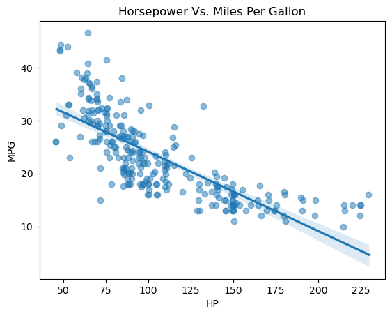

*The scatterplot shows the negative correlation between **hp** and **mpg**. What a twist! Having a car with high horsepower doesn't mean high fuel efficiency. The higher the horsepower of a car engine, the fewer miles it travels per gallon. Stronger engines consume more fuel.*

## *5. Brand Vs. Miles Per Gallon*

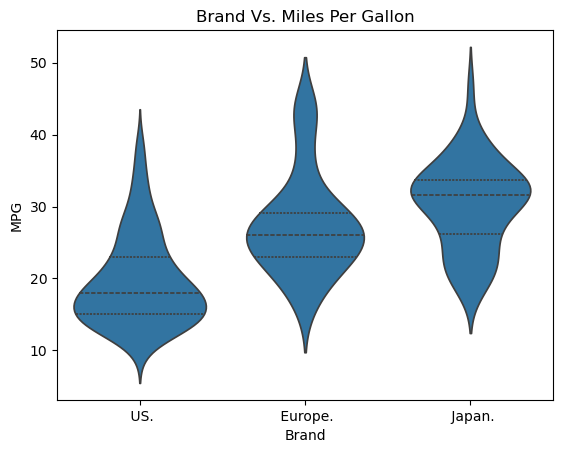

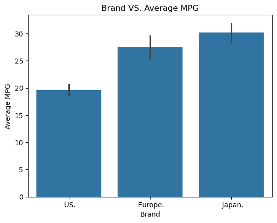

*According to the previous violin plot, we can clearly see, the **Japanese** brands have the highest median fuel efficiency, and the **US** brands have the lowest mpg median. The bar plots shows the average mpg for each brand. **Japan** brands have the highest mpg on average, while the **US** brands have the lowest mpg on average. **European** brands average mpg is much closer to the **Japan** brands mpg.*

## *6. Brand Vs. Cubicinches*

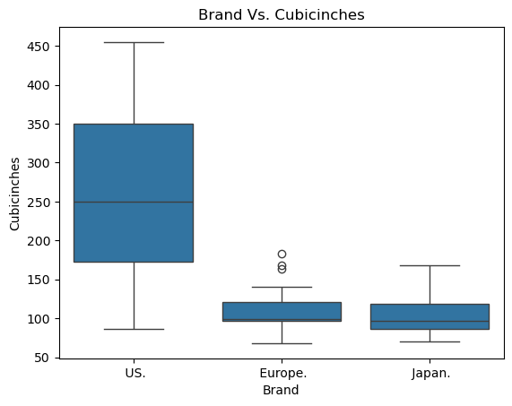

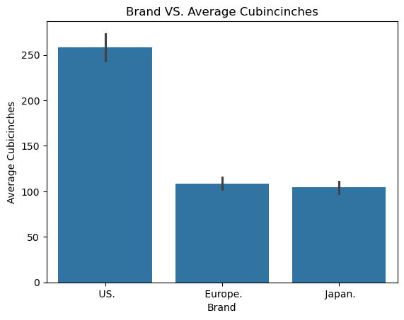

*The **US** brands tend to have a larger size than the **European** and **Japanese** brands on average and hence heavier, as we proved earlier. That's why the US brands travel fewer miles per gallon. **Less fuel efficiency**.*

## *7. Brand Vs. Time-To-60*

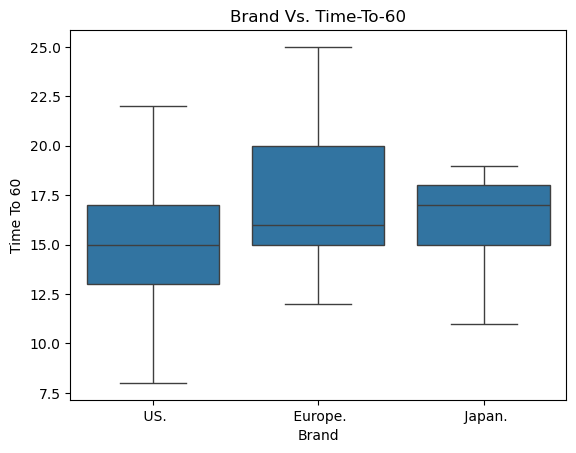

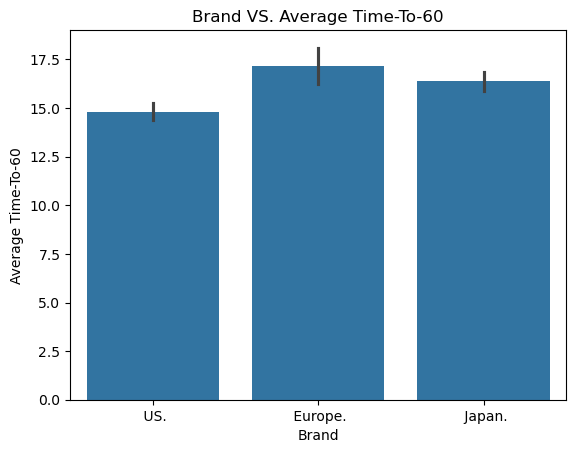

*As we can see, the **US** brands tend to have less time to reach their speed of 60 miles per hour than the **European** and **Japanese** brands on average and hence have more acceleration and speed. Based on a previous scatterplot, The **US** brands tend to have highest horsepower than the other brands as **hp** and **time-to-60** are negatively correlated.*

## *8. Year Vs. Miles Per Gallon*

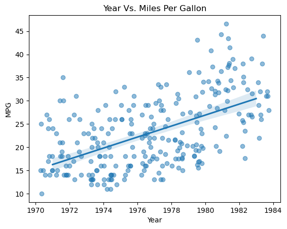

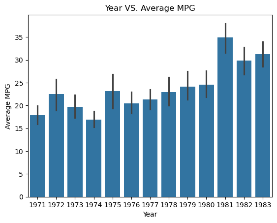

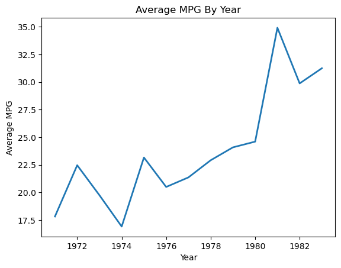

*All the previous plots: the scatterplot, the bar chart, and the line plot, all show the positive correlation between **year** and **mpg**. Overtime, the car models in the data were improved regarding fuel consumption and have higher fuel efficiency. Maybe due to environmental awareness and competition between brands in reducing fuel costs and carbon dioxide emissions.*

## *9. Year Vs. Number of Cylinders*

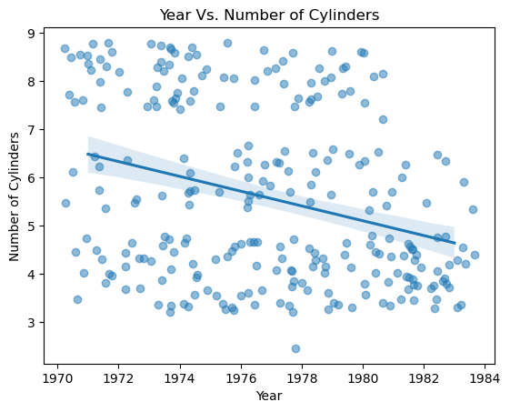

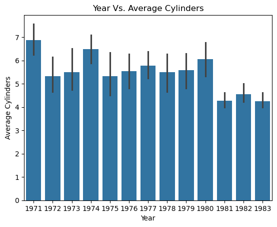

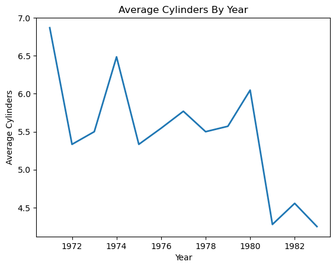

*Now, it is very obvious that overtime, the cars in the data have engines with less number of cylinders. It is very direct in the scatterplot and the line plot.*

## *10. Year Vs. Weights*

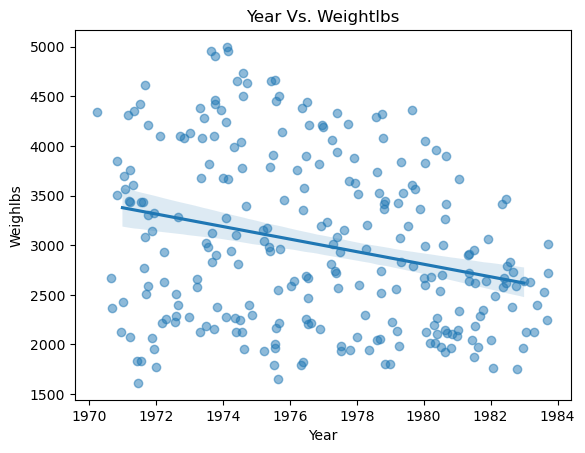

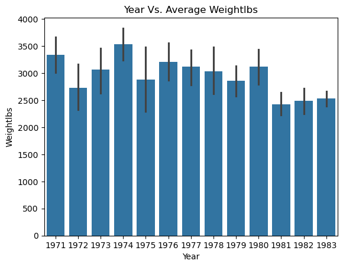

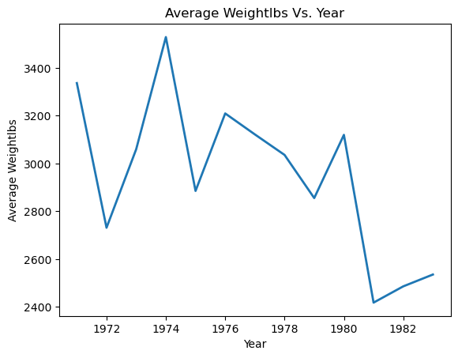

*The weight of cars in the data follows a decreasing trend overtime. New cars are relatively lighter in weight.*